# Week 3: MVPA: Specification

EDEP 625 Structural Equation Modeling

Susanne DeVore, PhD

2026-10-14

# notes

# Model specification

- Which variables are included in the model
- Which variables are related to which
- How are variables related to each other
- Based on the relationships, what is the model-implied covariance?

# Agenda

- Paper Discussion
- Terminology
- Systems of Equations as Path Diagrams
- Model-implied covariance
- Mini Project 1
- R/lavaan gui

# Paper Discussion

Go to Lamaku > quizes > W3 Reading Summary

Individually do the quiz

## Paper Discussion

- Theoretical motivation for the variables in the model?
- Were any variables left out?

# Terminology

## Measured vs. latent variables

**Measured** (**observed**) variables are recorded directly in the data.

- Ex: **reading score**, **books at home**, **parent education**.

**Latent** variables are *not* observed directly

- they are inferred from patterns among measured variables
- typically not easily captured by a single variable
- Ex: **academic performance**, **intelligence**, **problem-solving ability**.

## Review

- Input/independent variables & output/dependent variables

## Exogenous vs. endogenous variables

- **Exogenous variables:** nothing in the model explains it, but it explains other things.
- **Endogenous variables:** are explained by another variable in the model.

$$\text{Books} = a_0 + a_1(\text{ParentEd}) + \zeta_B$$
$$\text{Reading} = b_0 + b_1(\text{Books}) + \zeta_R$$

## Review

Residuals:

## Disturbance

- Model level: Var(disturbance) the part of an endogenous variable’s variance that isn’t explained by the model
- **Exogenous** variables have no disturbance — nothing in the model predicts them.

In our example, books at home and reading score each get a disturbance; parent education does not.

## Review

**Parameters** are the quantities the model estimates:

- What parameters do we estimate in a regression model?

## SEM Parameters

**Parameters** are the quantities the model estimates:

- path coefficients,
- variances of exogenous variables,
- disturbance of endogenous variables,
- Covariances among exogenous variables

## Pause & Recap

Contrast these terms from regression and their counterparts in SEM

1. Input/Output (dependent/independent) vs exogenous/endogenous
2. Residuals vs disturbance

## Pause & Recap 2

1. What are parameters we estimate in regression?
2. What about in SEM?

## Systems of Equations as Diagrams

Same model, two representations — matching colors show what maps to what.

$$\text{Books} = a_0 + \color{#E07B1A}{a_1}\,\text{ParentEd} + \color{#C81E7A}{\zeta_B}$$

$$\text{Reading} = b_0 + \color{#2C6FB5}{b_1}\,\text{Books} + \color{#6FA80F}{\zeta_R}$$

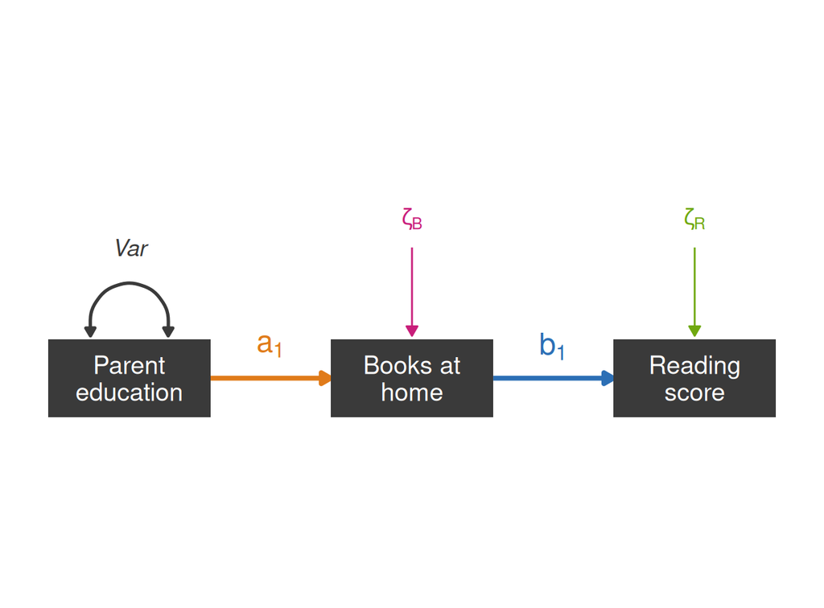

## Key rules for Diagrams

- Measured Variables: rectangles/squares
- Latent Variables: Ovals/circles
- Path Coefficients: Straight, single-headed arrows from predictor to predicted (theory-driven)
- Disturbance: Arrow from Disturbance pointing to the endogenous variable (mandatory)
- Covariance: Curved, double-headed arrow (between two exogenous variables)

## Examples

Read each of the following models. For each, answer the same three questions.

1. What relationships does it predict?
2. Which variables are Exogenous vs. endogenous?
3. What parameters does it estimate?

## Example 1

$$\text{Motivation} = a_0 + a_1(\text{Support}) + \zeta_M$$
$$\text{Grades} = b_0 + b_1(\text{Motivation}) + \zeta_G$$

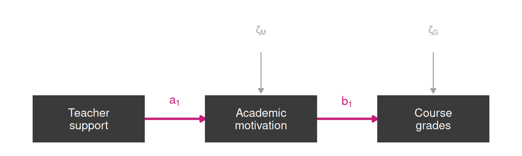

## Example 2

$$\text{Engagement} = a_0 + a_1(\text{Involvement}) + a_2(\text{SES}) + \zeta_E$$
$$\text{Homework} = b_0 + b_1(\text{Engagement}) + \zeta_H$$
$$\text{Grade} = c_0 + c_1(\text{Homework}) + \zeta_G$$

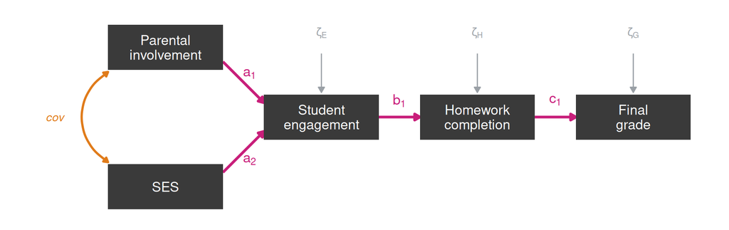

## Example 3

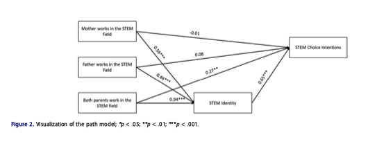

Pfeuffer et al. (2025), Figure 2: path model for STEM choice intentions

# Model Implied Covariance

## Model-implied covariance matrix

- Model-implied covariance is determined by tracing rules
- Tracing rules are derived algebraically.

## Review

- Why do we need the model-implied covariance matrix?
- Conceptually, how do we minimize distance between the observed & model-predicted matrices?

Key concepts: maximum likelihood function, gradient descent, update rule

## Getting Model-implied cov

First identify the paths using tracing rules:

1. A route may go backward against an arrowhead, then forward with an arrowhead — but never forward-then-backward.
2. Never pass through the same variable twice in one route (no loops).
3. A route may pass through at most one curved double-headed (covariance) arrow, and only at the route’s turning point.

## Getting model-implied covariance 2

Then get the covariance using the paths

1. Find every valid route between the two variables (following the rules above).
2. For each route, multiply together all the path coefficients (and the one correlation/covariance term, if a curved arrow is involved).
3. Multiply the whole product by the variance of the route’s ultimate common source variable.
4. Sum the contributions across all valid routes — that sum equals the total covariance between the two variables.

## Example: Books as a mediator

The model in two forms — we’ll build its **model-implied covariance matrix** one cell at a time by *tracing*.

$$\text{Books} = a_0 + a_1\,\text{ParentEd} + \zeta_B \qquad \text{Reading} = b_0 + b_1\,\text{Books} + \zeta_R$$

*P = Parent ed · B = Books · R = Reading*

## Trace 1 — Var(Parent ed)

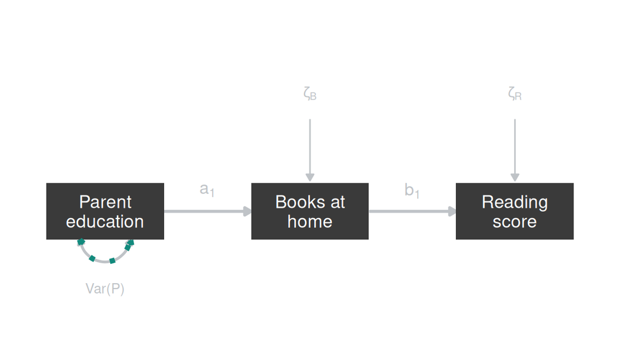

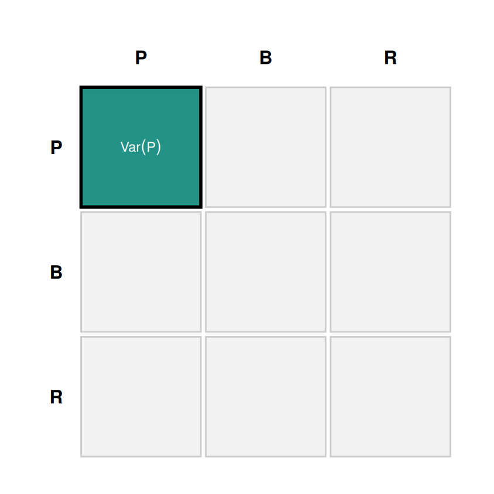

**Var(P):** ParentEd is exogenous — its variance is a free parameter. Nothing to trace.

## Trace 2 — Cov(Parent ed, Books)

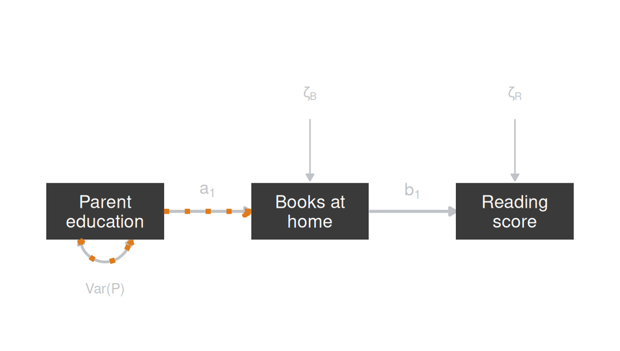

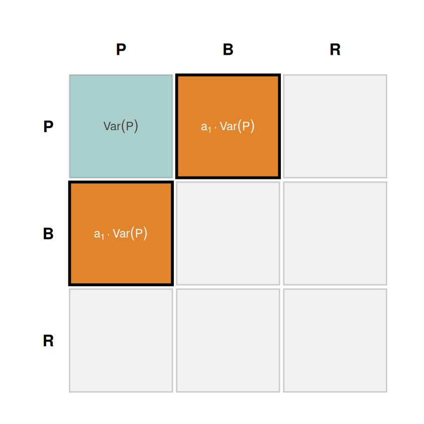

## Trace 3 — Var(Books)

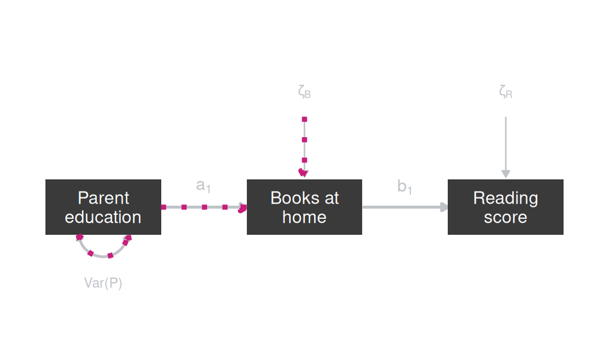

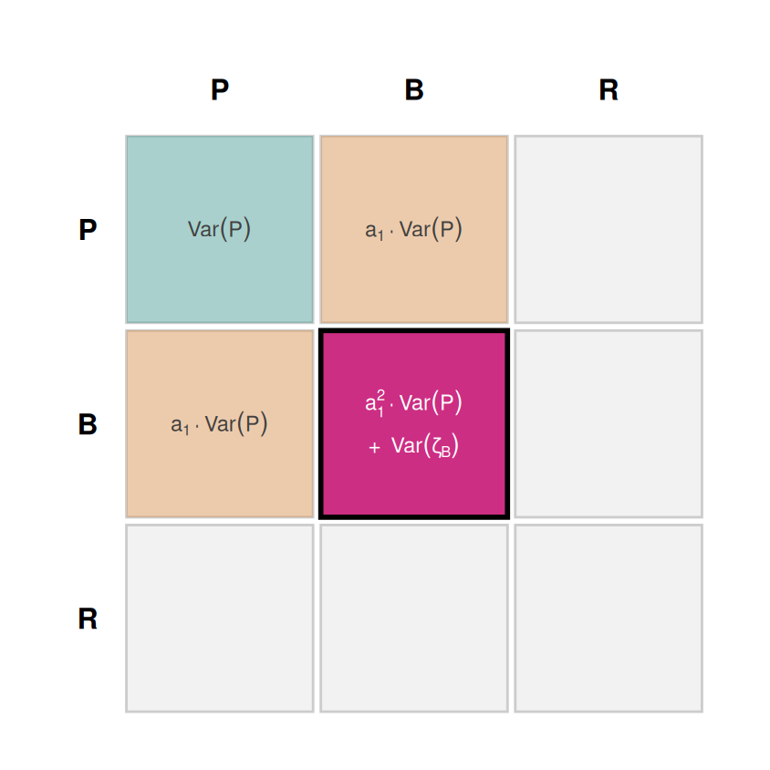

## Trace 4 — Cov(Parent ed, Reading)

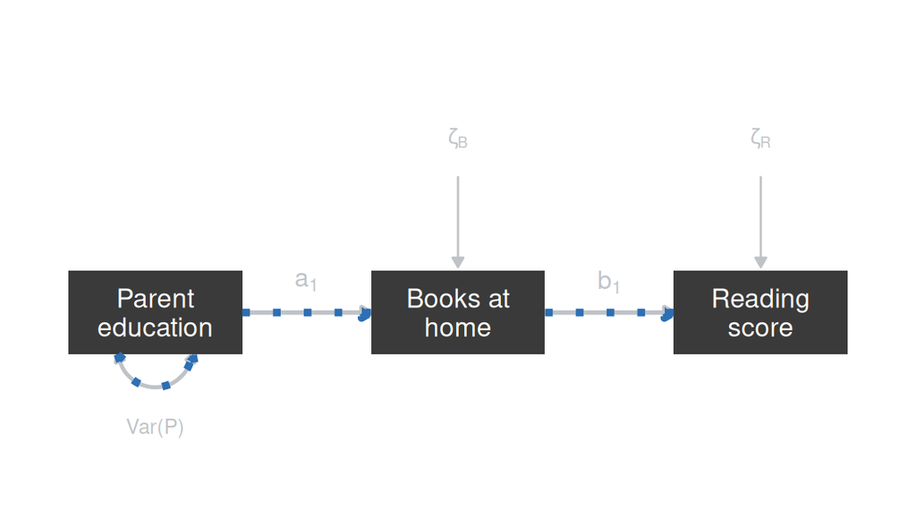

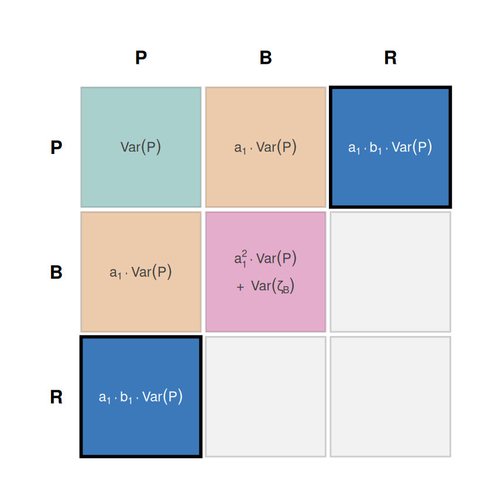

**Cov(P, R):** one route P→B→R. Multiply a₁·b₁, then × Var(P).

## Trace 5 — Cov(Books, Reading)

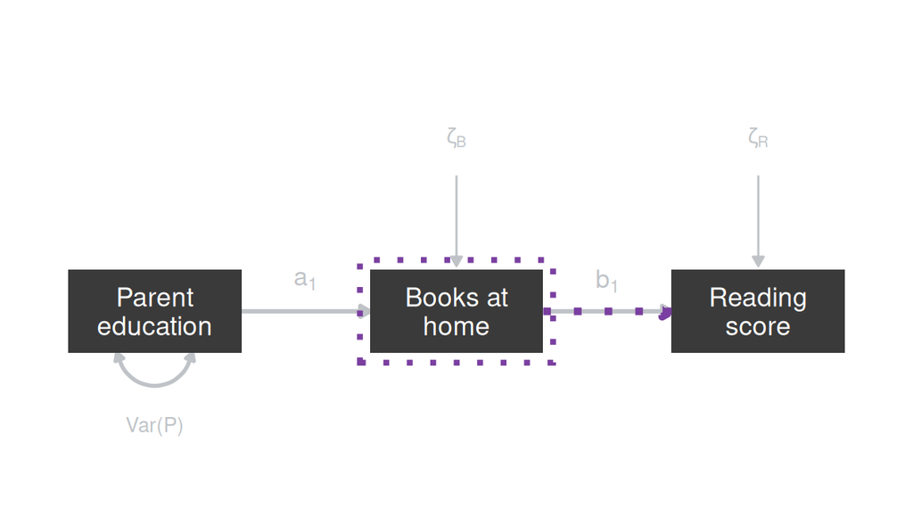

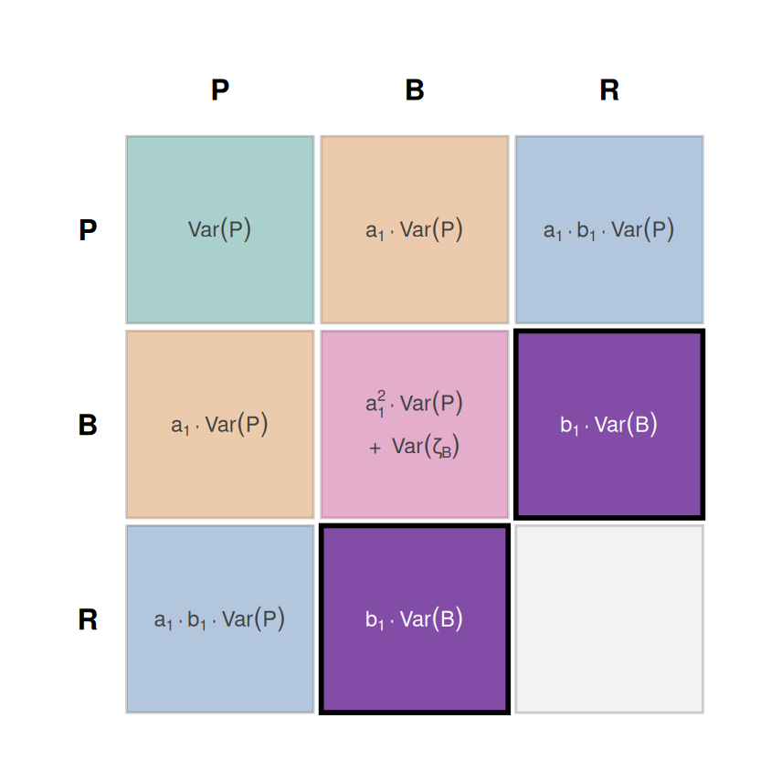

**Cov(B, R):** route B→R (b₁) × the variance of B we already found → b₁·Var(B).

## Trace 6 — Var(Reading)

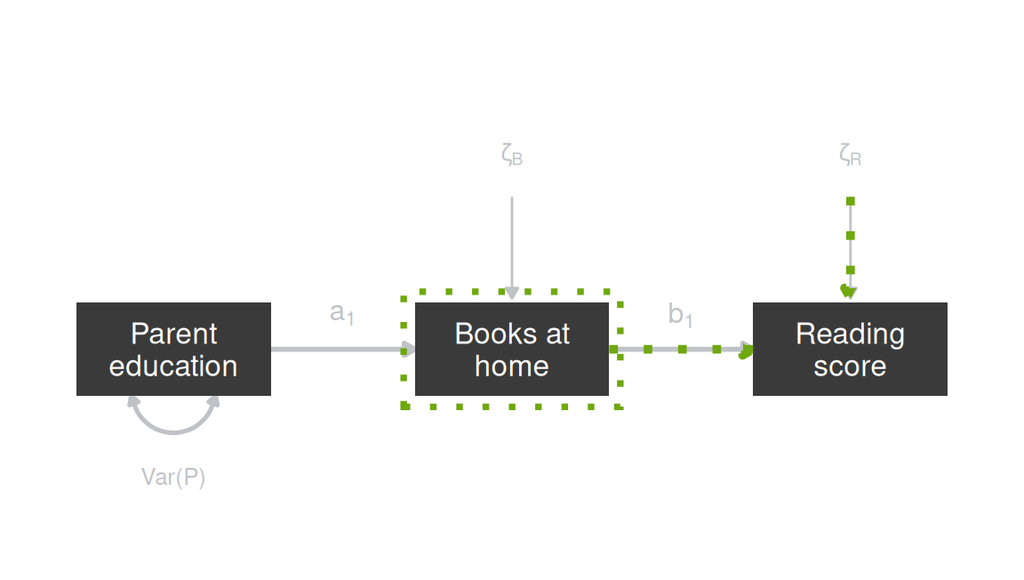

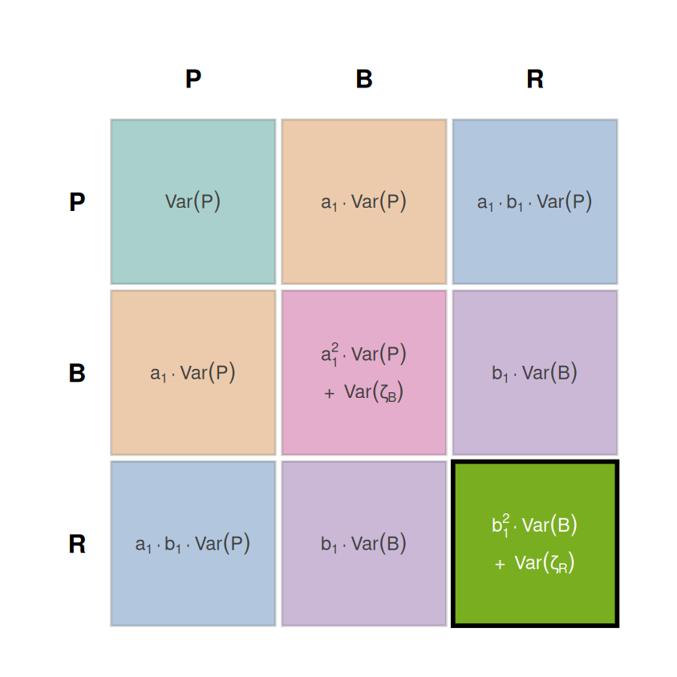

**Var(R):** up-and-back through B → b₁²·Var(B); plus its own disturbance → Var(ζ_R). Sum.

## Practice

$$\text{Motivation} = a_0 + a_1\,\text{Support} + \zeta_M \qquad \text{Grades} = b_0 + b_1\,\text{Motivation} + \zeta_G$$

*S = Support · M = Motivation · G = Grades*

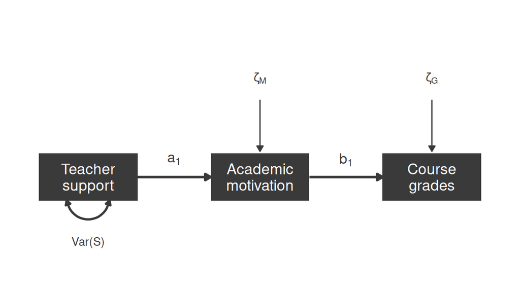

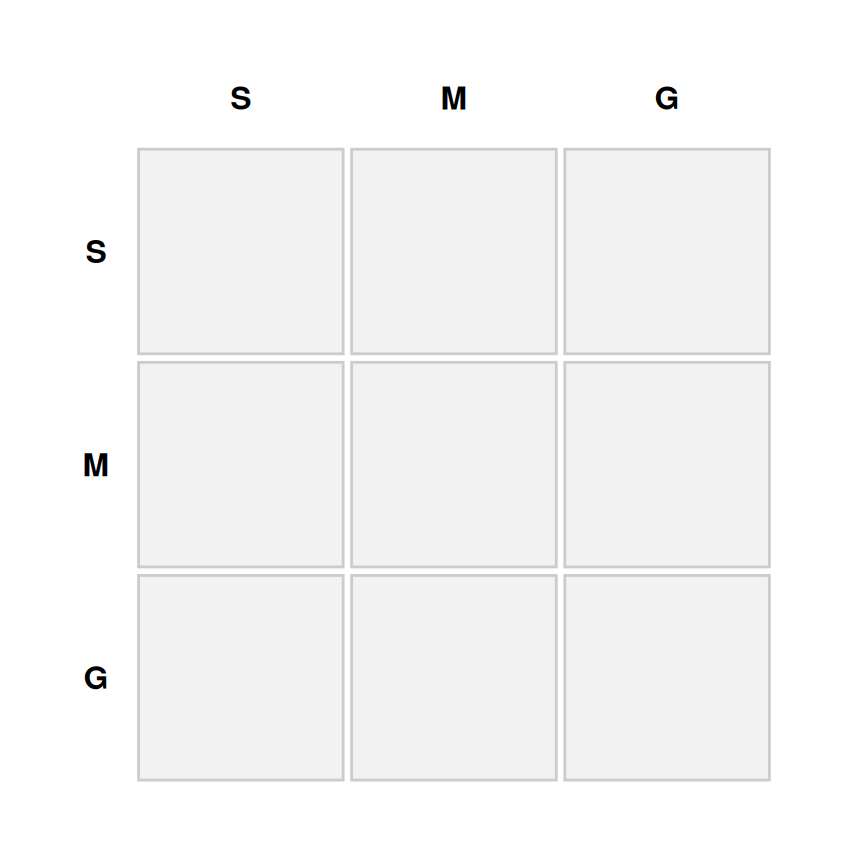

# Mini-project 1

# Lavaan GUI

- Specifying a model in the (GUI)[https://solo-fsw.shinyapps.io/lavaangui/]

# Rlab

Brainstorm for Mini-project 1

- Use your data and a research question you submitted last week
- Familiarize with the Lavaan GUI
- How would you specify your own measured variable path analysis model?
- Specify in the GUI
- Submit

## Up Next

Identification & Fit Indices

- Prep: Read Parry 2024 (2 pg summary if fit indices)
- In 3 weeks: Methods walk-through: Alana, Mia, Alex, Bocar
- In 4 weeks: Mini-project 1